# Michal Kuderski — Data Analyst

Skip to content

Michal Kuderski

Healthcare Data Analyst

**Role**

Healthcare  
Data Analyst

**Education**

B.S. Statistics  
NIU · 2026

**Stack**

SQL · Postgres  
Python · R  
SAS · Excel

**Status**

Open to roles

**Location**

Romeoville, IL

Medicare claims · Illinois psychiatry · 2023

Healthcare Data Analyst · Claims Analytics · SQL & Excel Reporting

# In Elk Grove Village, 76.7% of psychiatric care happens over the phone.

In Chicago, it's **1.9%**.

I analyze healthcare, claims, and operations data to turn messy records into clear decision support — combining statistics, SQL, PostgreSQL, Excel dashboards, and reimbursement analysis to identify cost drivers, utilization patterns, provider variation, and practical next steps. This finding is from a CMS Medicare psychiatry claims analysis of **2,460** Illinois claim records across **692** providers.

View Medicare Case Study View Resume Contact Me

Share of psychiatric services delivered by telephone

Illinois · 2023 · by provider city

Elk Grove Village76.7%

DeKalb52.3%

Chicago1.9%

**View data table**

| City | Telephone share |
| --- | --- |
| Elk Grove Village | 76.7% |
| DeKalb | 52.3% |
| Chicago | 1.9% |

For recruiters — 5-second scan

Healthcare analytics project using CMS Medicare claims, SQL/PostgreSQL, Excel dashboards, reimbursement analysis, HCPCS/CPT codes, KPI reporting, and provider outlier detection.

Healthcare Analytics CMS Medicare Claims SQL / PostgreSQL Excel Dashboards Reimbursement Analysis HCPCS / CPT Coding KPI Reporting Provider Outlier Detection

**Record**

CMS-2023-IL

**Source**

Medicare Physician & Other Practitioners

**Scope**

Illinois ·  
Psychiatry

**Rows**

2,460

**Built with**

PostgreSQL  
Excel

**Period**

Jan – Mar 2026

CASE 01

## Medicare Provider Spending Analysis

CMS Medicare Part B Claims · Illinois Psychiatry · 2023

**Tools:** PostgreSQL · SQL · Excel · CMS Medicare Part B data  
**Methods:** CTEs · window functions · reimbursement analysis · KPI dashboarding · outlier detection

Who actually gets to see a psychiatrist in Illinois?

This project analyzes **2,460** CMS Medicare psychiatry claim records across **692** Illinois providers and **96** procedure codes to evaluate healthcare spending, utilization, reimbursement patterns, and provider-level cost variation.

I built a normalized PostgreSQL database, wrote analytical SQL queries using CTEs, subqueries, aggregations, and window functions, and developed an Excel dashboard to summarize key performance indicators such as Medicare payment per service, cost per beneficiary, procedure-level spending, and charge-to-payment differences.

The analysis surfaced two important decision points: **CPT 99214** was the largest cost driver at **$5.6M**, representing **20.8%** of Medicare payments, and telephone-based service delivery varied sharply by city, with Elk Grove Village at **76.7%** compared with Chicago at **1.9%**. These findings suggest that healthcare leaders should evaluate not only provider spending, but also access barriers, care delivery mode, and whether transportation or telehealth infrastructure may be limiting patient access.

Question

Where are psychiatry costs and access patterns concentrated?

Finding

**CPT 99214** drove **20.8%** of Medicare payments, and telephone-service share varied sharply by city — from **76.7%** in Elk Grove Village to **1.9%** in Chicago.

Recommendation

Evaluate telehealth access, transportation support, and provider distribution before assuming staffing is the only constraint.

The question

A community mental health organization has a fixed budget and a service area spanning dense city blocks and spread-out suburbs. Where should it put clinicians — and where is the constraint something other than headcount?

The data

CMS publishes every Medicare Part B claim line by provider and procedure code. I filtered the 2023 file to **Illinois psychiatry** — **2,460** claim records across **692** providers — and loaded it into a normalized PostgreSQL schema: providers, procedure codes, and a utilization fact table.

The method

Six analytical queries using CTEs, window functions, and subqueries. Five answered the expected cost questions. The sixth asked something the brief didn't: **how are these services actually being delivered?**

Why it matters

The trap I avoided

Submitted charges are **not** a cost measure. Providers routinely bill 2–5× the allowed amount, so any analysis anchored on charges overstates cost badly. I anchored on actual payment throughout.

What I'd do next

Join against provider density and transit coverage by ZIP to separate "no provider nearby" from "provider nearby but unreachable." The current data can't distinguish them — and the fix for each is different.

Submitted charges vs. what Medicare paid

Illinois psychiatry · 2023 · all claim lines

$27.2M

$43.5M

Paid by Medicare Balance of submitted charges

Providers received **38¢ per dollar billed**. That 2.6× ratio is entirely normal for Medicare — which is the point: **submitted charges are not a cost measure**, and analysis that treats them as one goes wrong quietly.

**View data table**

| Measure | Amount | Share |
| --- | --- | --- |
| Submitted charges | $70.7M | 100% |
| Medicare payment | $27.2M | 38.5% |
| Balance | $43.5M | 61.5% |

2,460

Claim records

Dataset scope

692

Providers

Dataset scope

6

Analytical queries

My contribution

3

Normalized tables

My contribution

7

Workbook sheets

My contribution

The six queries

Q1Which specialties generate the highest total Medicare spending?Aggregation

Q2Average Medicare payment per service, by specialtyCTE

Q3Which providers are payment-per-service outliers within their own specialty?Window fn

Q4Which procedure codes drive the highest aggregate spending?Join · rank

Q5Cost-efficiency variation across providers in the same specialtySubquery

Q6**Telehealth delivery share by city** — the question the brief didn't askOriginal

Top cost driver: **CPT 99214** (established outpatient visit, 30–39 min) at **$5.6M** — **20.8%** of all payments. The top five codes account for **55.6%** of Medicare spending in this cohort.

Schema — three normalized tables

[figure not shown]

`providers` and `hcpcs_codes` are reference dimensions — one row per NPI, one row per procedure code. `utilization` is the fact table: one row per provider × procedure × place of service, holding every volume and payment column.

One query, in full — the rest are in the script

Query 3.3 — provider outlier detection (excerpt)

CTE + window function · full query in Deliverables below

```
WITH provider_metrics AS (
    -- Individual provider-level payment per service
    SELECT
        p.npi,
        p.first_name,
        p.last_org_name,
        p.credentials,
        p.city,
        p.provider_type                                                 AS specialty,
        SUM(u.tot_srvcs)                                                AS total_services,
        SUM(u.tot_benes)                                                AS total_beneficiaries,
        ROUND(SUM(u.avg_medicare_payment * u.tot_srvcs), 2)             AS total_payment,

        -- Provider's own payment per service
        ROUND(
            SUM(u.avg_medicare_payment * u.tot_srvcs) /
            NULLIF(SUM(u.tot_srvcs), 0),
        2)                                                              AS provider_pay_per_svc,

        -- Specialty average payment per service (window function over specialty group)
        ROUND(
            SUM(SUM(u.avg_medicare_payment * u.tot_srvcs)) OVER (PARTITION BY p.provider_type) /
            NULLIF(SUM(SUM(u.tot_srvcs)) OVER (PARTITION BY p.provider_type), 0),
        2)                                                              AS specialty_avg_pay_per_svc

    FROM utilization u
    JOIN providers p ON u.npi = p.npi
    GROUP BY p.npi, p.first_name, p.last_org_name, p.credentials, p.city, p.provider_type
)
-- … continues: ranks each provider within specialty with RANK() OVER (...),
-- computes percent deviation from the specialty mean, and flags anything
-- beyond ±50% as an outlier. Full query in medicare_analytics.sql.
```

Dashboard preview — the KPIs, before you download anything

Pulled directly from the seven-sheet Excel workbook below — rendered natively here so the work is visible without a download.

KPI summary

Illinois psychiatry · 2023 · full cohort

$27.2M

Total Medicare payment

$70.7M

Total submitted charges

$51.03

Avg payment per service

$202.93

Avg payment per beneficiary

Medicare payment by procedure code

Top 5 of 96 codes billed · bars scaled to the top code

99214$5.6M · 20.8%

99213$3.1M · 11.3%

99232$2.7M · 9.9%

K1034$1.9M · 7.1%

90833$1.8M · 6.5%

**View data table**

| Code | Description | Payment | Share |
| --- | --- | --- | --- |
| 99214 | Est. outpatient visit, 30–39 min | $5.6M | 20.8% |
| 99213 | Est. outpatient visit, 20–29 min | $3.1M | 11.3% |
| 99232 | Subsequent hospital care, ≥35 min | $2.7M | 9.9% |
| K1034 | COVID-19 test, self-administered | $1.9M | 7.1% |
| 90833 | Psychotherapy w/ E&M, 30 min | $1.8M | 6.5% |

Telephone-service share, by city

Illinois · 2023 · top cities by share

Elk Grove Village76.7%

DeKalb52.3%

Plainfield25.6%

Morris21.4%

Pekin18.8%

Chicago1.9%

**View data table**

| City | Telephone share | Providers |
| --- | --- | --- |
| Elk Grove Village | 76.7% | 1 |
| DeKalb | 52.3% | 1 |
| Plainfield | 25.6% | 1 |
| Morris | 21.4% | 1 |
| Pekin | 18.8% | 1 |
| Chicago | 1.9% | 22 |

What this proves I can do for a healthcare team

—

Analyze claims and utilization data to find real patterns, not just totals

—

Build KPI dashboards that summarize cost, volume, and access in one view

—

Identify and explain cost drivers at the procedure level

—

Detect provider-level variation and flag outliers systematically

—

Translate findings into concrete operational recommendations

—

State a finding's limitations clearly, instead of overselling it

Limitations

- Claims data shows utilization and payment patterns — not clinical outcomes, care quality, or patient satisfaction.
- It reflects what was billed, not appointment availability or how long a patient waited to be seen.
- Telephone-service share is a proxy for access, not a direct measurement of transportation barriers or provider capacity — it shows how care was delivered, not why.
- Several of the highest telephone-share cities — Elk Grove Village and DeKalb among them — have only one billing provider. A single provider's practice style can dominate a city's percentage, so city-level findings here are leads worth verifying against a larger sample, not standalone conclusions.

Deliverables — open any of them

Executive Summary

Findings, PDF · executive_summary.pdf

Download SQL Analysis

Schema + six queries · medicare_analytics.sql

Download Excel Dashboard

KPIs, pivots & charts · 7 sheets

GitHub Repository

Medicare-Provider-Spending-Analysis

**About**

Michal  
Kuderski

BIO

## About

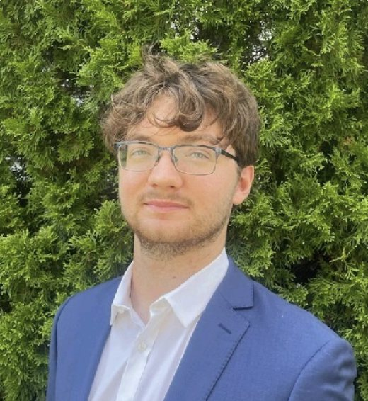

Michal Kuderski  
Data Analyst · Illinois

I'm a recent graduate with a **B.S. in Statistics from Northern Illinois University**, and most of what I enjoy about this work happens in the gap between a number being correct and a number being useful.

The Medicare project is a good example. Five of my six queries answered the cost questions you'd expect. The sixth — the one about how services were actually delivered — is the only one that would have changed a decision. I've gotten more interested in finding that sixth query.

Healthcare is where I've gone deepest, because the data is messy in ways that matter. A submitted charge isn't a cost. A missing provider isn't the same as an unreachable one. Getting those distinctions right is most of the job.

But the shape of the problem isn't unique to healthcare. It's the same in **supply chain and logistics**: a system moving finite resources through constrained paths, generating data about it, and not always noticing what that data is saying. I'm interested in analyst work anywhere that pattern shows up — healthcare operations, supply chain management, logistics and logistics technology, or any industry that needs someone to look carefully at the numbers and say what they actually mean.

**Also**

Three further  
projects

WORK

## Additional analytics work

Supporting projects that round out the toolkit — the Medicare case study above remains the primary work.

### Excel reporting, automated end to end

Python · pandas · openpyxl

A recurring spreadsheet clean-and-report cycle rebuilt as a Python notebook — pandas for the transformation, openpyxl for the formatted output. The manual version took an afternoon; this one takes a cell execution.

PythonpandasopenpyxlJupyter

[View notebook](https://github.com/MichalKuderski/Digital-Workflow-Improvement-Automation)

### Retail promotion uplift — Quantium simulation

Apr – Jun 2025

50,000+ transactions, benchmark-store matching, and uplift testing to separate real promotional lift from seasonal noise. Surfaced roughly **$200K** in projected revenue opportunity, with prioritized recommendations for category management.

RUplift testingSegmentationEDA

[View project](https://github.com/MichalKuderski/Quantium-Retail-Data-Analysis)

### Predicting academic outcomes from behavioral data

Apr 2025

Random forest classifiers, k-means clustering, and regression across social and behavioral variables — to identify which factors actually move student performance, and which only look like they do before controls.

RRandom forestK-meansRegression

[View findings](https://github.com/MichalKuderski/Student-Performance-Predictive-Modeling)

**Credentials**

Education,  
tools, domain

TOOLS

## Education & toolkit

### Education

- **B.S. Statistics**, May 2026 · GPA 3.7 Northern Illinois University · DeKalb, IL
- Minors in Mathematics & Geography Honors Program
- Regression Analysis · Statistical Inference · Design & Analysis of Experiments (SAS) Relevant coursework
- English (Native) · Polish (Fluent) Languages

### Certifications

- Meta Data Analyst with GenAI Coursera
- Intermediate SQL DataCamp
- Data Analysis in Excel DataCamp

### Experience

- **Certified Tennis Instructor** Naperville Park District · Apr 2025 – present
- Structured instruction for youth participants; personalized improvement plans tracked against performance trends.

### Query & program

- **SQL / PostgreSQL** — CTEs, window functions, subqueries, schema design
- **Python** — pandas, NumPy, scikit-learn, openpyxl
- **R** — RStudio, modeling and EDA
- **SAS** — design and analysis of experiments
- **Git** · **Jupyter**

### Analyze & report

- **Excel** — pivot tables, advanced formulas, KPI dashboards
- **Power BI** — dashboard reporting
- Regression, ANOVA, hypothesis testing
- Predictive modeling — random forests, k-means
- A/B and uplift testing · feature engineering

### Healthcare domain

- CMS Medicare claims · Part B utilization
- HCPCS/CPT coding · ICD-9 / ICD-10
- Medicare reimbursement structure — allowed vs. paid vs. submitted
- Provider outlier detection · cost-per-beneficiary KPIs
- Healthcare supply chain management (HSCM)

**Resume**

Two versions,  
same facts

CV

## Resume

Two versions depending on what you're hiring for. The healthcare one goes deeper on claims, reimbursement, and HSCM; the general one leads with the statistics and modeling work.

[figure not shown]

### Standard Data Analyst

Statistics · modeling · analytics

View Standard Data Analyst Resume Download

[figure not shown]

### Healthcare Data Analyst

Claims · reimbursement · HSCM

View Healthcare Data Analyst Resume Download

**Contact**

Open to  
2026 roles

END

## Let's talk about your data.

If you're hiring an analyst — healthcare, supply chain, logistics, or anywhere the questions are about cost, flow, and where the two stop lining up — I'd like to hear from you.

mkuderski21@gmail.com (630) 828-3189 [LinkedIn](https://www.linkedin.com/in/michal-kuderski-4b10a8230/) [GitHub](https://github.com/MichalKuderski)